# CMPINF 2100: Midterm exam

## Xavier A. Acosta Santiago

### Assigned: Tuesday of Week 09 at 11:00PM

### DUE: Tuesday of Week 10 at 11:59PM

You may add as many code and markdown cells as you see fit to answer the questions.

## You are NOT allowed to collaborate with anyone on this exam.

## Overview

You will demonstrate your ability to merge, group, summarize, visualize, and find patterns in data. This exam uses data associated with a manufacturing example. An overview of the goals, considerations, CSV files, and variables within the data is provided in a presentation on Canvas. Please read through those slides before starting the exam.

The data are provided in 5 separate CSV files. The CSV files are available on Canvas. You MUST download the files and save them to the same working directory as this notebook.

The specific instructions in this notebook tell you when you must JOIN the data together. Please read the problems carefully.

The overall objective of this exam is to JOIN data from multiple files in order to explore and find interesting patterns between the machine operating conditions and supplier information. You will report your findings within this notebook by displaying Pandas DataFrames and statistical visualizations via Seaborn and matplotlib when necessary.

## Import modules

You are permitted to use the following modules on this exam.

```python
import numpy as np
import pandas as pd
import matplotlib.pyplot as plt

import seaborn as sns
```

You may also use the following functions from scikit-learn on this exam.

```python
from sklearn.preprocessing import StandardScaler
from sklearn.cluster import KMeans
from sklearn.decomposition import PCA
```

You may also use the following sub module from SCIPY.

```python
from scipy.cluster import hierarchy
```

## Problem 01

The file names for the 3 machine data sets are provided as strings in the cell below. You are required to read in the CSV files and assign the data to the `m01_df`, `m02_df`, and `m03_df` objects. The data from machine 1 will therefore be associated with `m01_df`, machine 2 is associated with `m02_df`, and machine 3 is associated with `m03_df`.

In this problem you must explore each of the three machine data sets.

You must perform the following **ESSENTIAL** activities:

- How many rows and columns are in each data set?
- What are the names and data types for each column?
- How many unique values are there for each column?
- How many missing values are there for each column?
- You must visually explore the MARGINAL behavior of the variables in the data. You must use visualizations appropriate for the DATA TYPE of the columns.

You must visually explore RELATIONSHIPS between variables in the data. You must use visualizations appropriate for the DATA TYPES. You must make sure that your visualizations can answer the following questions:

- How many unique values for `Batch` are associated with each MACHINE (data set)?
- How many cell phone cases are associated with each `Batch` value for each MACHINE (data set)?
- Do the summary statistics of the OPERATING VARIABLES `x1` through `x4` vary across the three MACHINES?
- Do the summary statistics of the OPERATING VARIABLES `x1` through `x4` vary across the `Batch` values?
- Do the relationships between the OPERATING VARIABLES `x1` through `x4` vary across the three MACHINES?
- Do the relationships between the OPERATING VARIABLES `x1` through `x4` vary across the `Batch` values?

At the conclusion of this problem, you **MUST** CONCATENATE the 3 MACHINE data sets into a single DataFrame. The single DataFrame must be named `machine_df`. Before concatenating, you **MUST** add a column `machine_id` to each DataFrame with the correct index value for that machine (1, 2, or 3). The concatenating DataFrame variable name is provided as a reminder to you below.

You may add as many markdown and code cells as you see fit to answer this question. Include markdown cells stating what you see in the figures and why you selected to use them.

SOLUTION

```python
# Define the files's for the 3 machine level CSV files

file_m01 = 'midterm_machine_01.csv'

file_m02 = 'midterm_machine_02.csv'

file_m03 = 'midterm_machine_03.csv'
```

```python
# read in the CSV files and name them accordingly

m01_df = pd.read_csv( file_m01 )

m02_df = pd.read_csv( file_m02 )

m03_df = pd.read_csv( file_m03 )
```

### Exploring each CSV file.

#### `m01_df`:

## Number of rows and columns.

```python
m01_df.shape
```

```
(5152, 7)
```

## Name and data types for each column.

```python
m01_df.dtypes
```

```
ID        object
Batch      int64
s_id       int64
x1       float64
x2       float64
x3       float64
x4       float64
dtype: object
```

## Unique values for each column.

```python
m01_df.nunique()
```

```
ID       5152
Batch      50
s_id      149
x1       5152
x2       5152
x3       5152
x4       5152
dtype: int64
```

## Missing values for each column.

```python
m01_df.isna().sum()
```

```
ID       0
Batch    0
s_id     0
x1       0
x2       0
x3       0
x4       0
dtype: int64
```

#### `m02_df`:

## Number of rows and columns.

```python
m02_df.shape
```

```
(5119, 7)
```

## Names and data types for each column.

```python
m02_df.dtypes
```

```
ID        object
Batch      int64
s_id       int64
x1       float64
x2       float64
x3       float64
x4       float64
dtype: object
```

## Unique values for each column.

```python
m02_df.nunique()
```

```
ID       5119
Batch      50
s_id      133
x1       5119
x2       5119
x3       5119
x4       5119
dtype: int64
```

## Missing values for each column.

```python
m02_df.isna().sum()
```

```
ID       0
Batch    0
s_id     0
x1       0
x2       0
x3       0
x4       0
dtype: int64
```

#### `m03_df`:

## Number of rows and columns.

```python
m03_df.shape
```

```
(4458, 7)
```

## Names and data types for each column.

```python
m03_df.dtypes
```

```
ID        object
Batch      int64
s_id       int64
x1       float64
x2       float64
x3       float64
x4       float64
dtype: object
```

## Unique values for each column.

```python
m03_df.nunique()
```

```
ID       4458
Batch      41
s_id      141
x1       4458
x2       4458
x3       4458
x4       4458
dtype: int64
```

## Missing values for each column.

```python
m03_df.isna().sum()
```

```
ID       0
Batch    0
s_id     0
x1       0
x2       0
x3       0
x4       0
dtype: int64
```

## Adding new column `machine_id` to each data frame.

```python
m01_df['machine_id'] = "machine_01"
m02_df['machine_id'] = "machine_02"
m03_df['machine_id'] = "machine_03"
```

```python
# concatenate the 3 DataFrames into a single DataFrame which includes the `machine_id` variable

machine_df = pd.concat([m01_df, m02_df, m03_df], ignore_index=True)
```

## Converting `Batch` to category.

```python
machine_df["Batch"] = machine_df["Batch"].astype("category")
```

```python
machine_df
```

|  | ID | Batch | s_id | x1 | x2 | x3 | x4 | machine_id |
| --- | --- | --- | --- | --- | --- | --- | --- | --- |
| 0 | B001-M01-S001 | 1 | 1 | 50.117118 | 102.167346 | 22.067812 | 13.889524 | machine_01 |
| 1 | B001-M01-S002 | 1 | 2 | 46.887333 | 112.266102 | 23.197330 | 13.064709 | machine_01 |
| 2 | B001-M01-S003 | 1 | 3 | 50.132744 | 103.674908 | 22.319933 | 13.647482 | machine_01 |
| 3 | B001-M01-S004 | 1 | 4 | 48.501042 | 107.143156 | 22.162947 | 14.077758 | machine_01 |
| 4 | B001-M01-S005 | 1 | 5 | 49.690442 | 102.120283 | 22.248696 | 13.728666 | machine_01 |
| ... | ... | ... | ... | ... | ... | ... | ... | ... |
| 14724 | B049-M03-S100 | 49 | 100 | 49.278415 | 102.089925 | 22.396979 | 13.753264 | machine_03 |
| 14725 | B049-M03-S101 | 49 | 101 | 49.264754 | 104.619874 | 21.977716 | 13.636539 | machine_03 |
| 14726 | B049-M03-S102 | 49 | 102 | 49.465358 | 102.867473 | 22.257845 | 13.678206 | machine_03 |
| 14727 | B049-M03-S103 | 49 | 103 | 49.751785 | 104.863427 | 22.461204 | 13.880084 | machine_03 |
| 14728 | B049-M03-S104 | 49 | 104 | 49.819212 | 104.075176 | 22.462165 | 13.853014 | machine_03 |

14729 rows × 8 columns

## Long Format

```python
machine_op_var = machine_df[['x1', 'x2', 'x3', 'x4']].copy()
```

```python
machine_op_var.melt(ignore_index=False)
```

|  | variable | value |
| --- | --- | --- |
| 0 | x1 | 50.117118 |
| 1 | x1 | 46.887333 |
| 2 | x1 | 50.132744 |
| 3 | x1 | 48.501042 |
| 4 | x1 | 49.690442 |
| ... | ... | ... |
| 14724 | x4 | 13.753264 |
| 14725 | x4 | 13.636539 |
| 14726 | x4 | 13.678206 |
| 14727 | x4 | 13.880084 |
| 14728 | x4 | 13.853014 |

58916 rows × 2 columns

```python
machine_op_var.reset_index().\
rename(columns={'index':'rowid'}).\
melt(id_vars=['rowid'])
```

|  | rowid | variable | value |
| --- | --- | --- | --- |
| 0 | 0 | x1 | 50.117118 |
| 1 | 1 | x1 | 46.887333 |
| 2 | 2 | x1 | 50.132744 |
| 3 | 3 | x1 | 48.501042 |
| 4 | 4 | x1 | 49.690442 |
| ... | ... | ... | ... |
| 58911 | 14724 | x4 | 13.753264 |
| 58912 | 14725 | x4 | 13.636539 |
| 58913 | 14726 | x4 | 13.678206 |
| 58914 | 14727 | x4 | 13.880084 |
| 58915 | 14728 | x4 | 13.853014 |

58916 rows × 3 columns

```python
machine_objects = machine_df[['ID','Batch','machine_id']].copy()
```

```python
id_cols = ['rowid'] + machine_objects.columns.to_list()
```

```python
machine_lf = machine_df.reset_index().\
rename(columns={'index':'rowid'}).\
melt(id_vars=id_cols, value_vars=machine_op_var.columns)
```

```python
machine_lf
```

|  | rowid | ID | Batch | machine_id | variable | value |
| --- | --- | --- | --- | --- | --- | --- |
| 0 | 0 | B001-M01-S001 | 1 | machine_01 | x1 | 50.117118 |
| 1 | 1 | B001-M01-S002 | 1 | machine_01 | x1 | 46.887333 |
| 2 | 2 | B001-M01-S003 | 1 | machine_01 | x1 | 50.132744 |
| 3 | 3 | B001-M01-S004 | 1 | machine_01 | x1 | 48.501042 |
| 4 | 4 | B001-M01-S005 | 1 | machine_01 | x1 | 49.690442 |
| ... | ... | ... | ... | ... | ... | ... |
| 58911 | 14724 | B049-M03-S100 | 49 | machine_03 | x4 | 13.753264 |
| 58912 | 14725 | B049-M03-S101 | 49 | machine_03 | x4 | 13.636539 |
| 58913 | 14726 | B049-M03-S102 | 49 | machine_03 | x4 | 13.678206 |
| 58914 | 14727 | B049-M03-S103 | 49 | machine_03 | x4 | 13.880084 |
| 58915 | 14728 | B049-M03-S104 | 49 | machine_03 | x4 | 13.853014 |

58916 rows × 6 columns

## Marginal behavior of all variables.

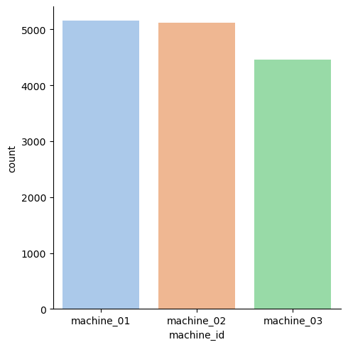

```python
sns.catplot( data = machine_df, x='machine_id', kind='count', palette='pastel')

plt.show()
```

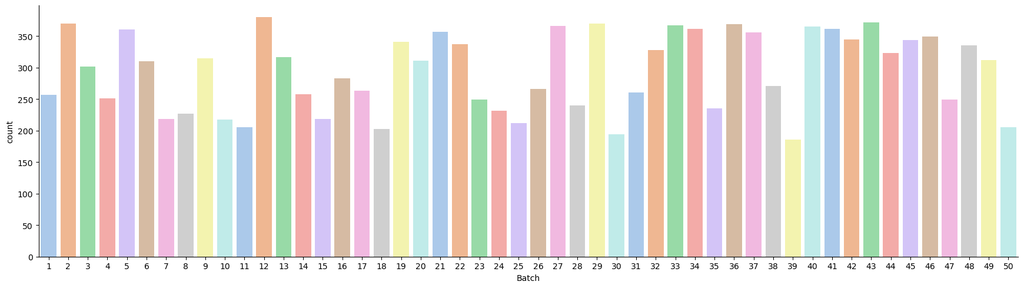

```python
sns.catplot( data = machine_df, x='Batch', kind='count', palette='pastel', aspect=3.5)

plt.show()
```

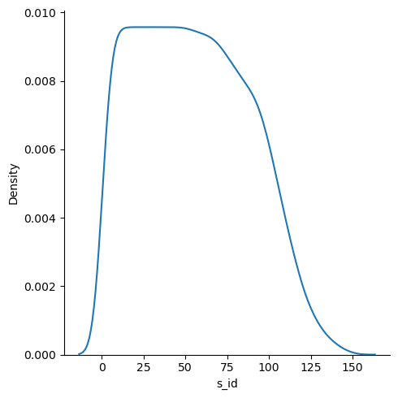

```python
sns.displot( data = machine_df, x='s_id', kind='kde')

plt.show()
```

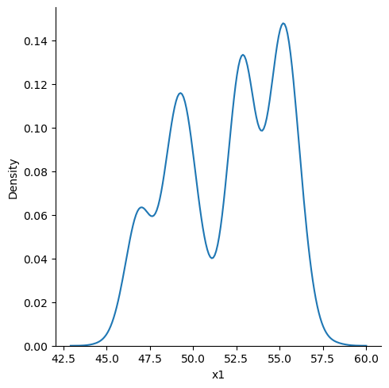

```python
sns.displot( data = machine_df, x='x1', kind='kde')

plt.show()
```

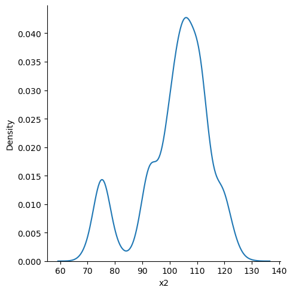

```python
sns.displot( data = machine_df, x='x2', kind='kde')

plt.show()
```

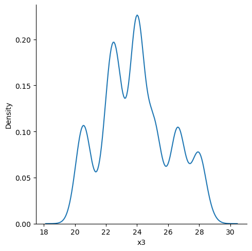

```python
sns.displot( data = machine_df, x='x3', kind='kde')

plt.show()
```

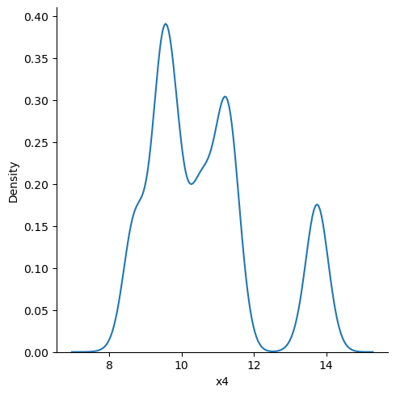

```python
sns.displot( data = machine_df, x='x4', kind='kde')

plt.show()
```

How many unique values for Batch are associated with each MACHINE (data set)?

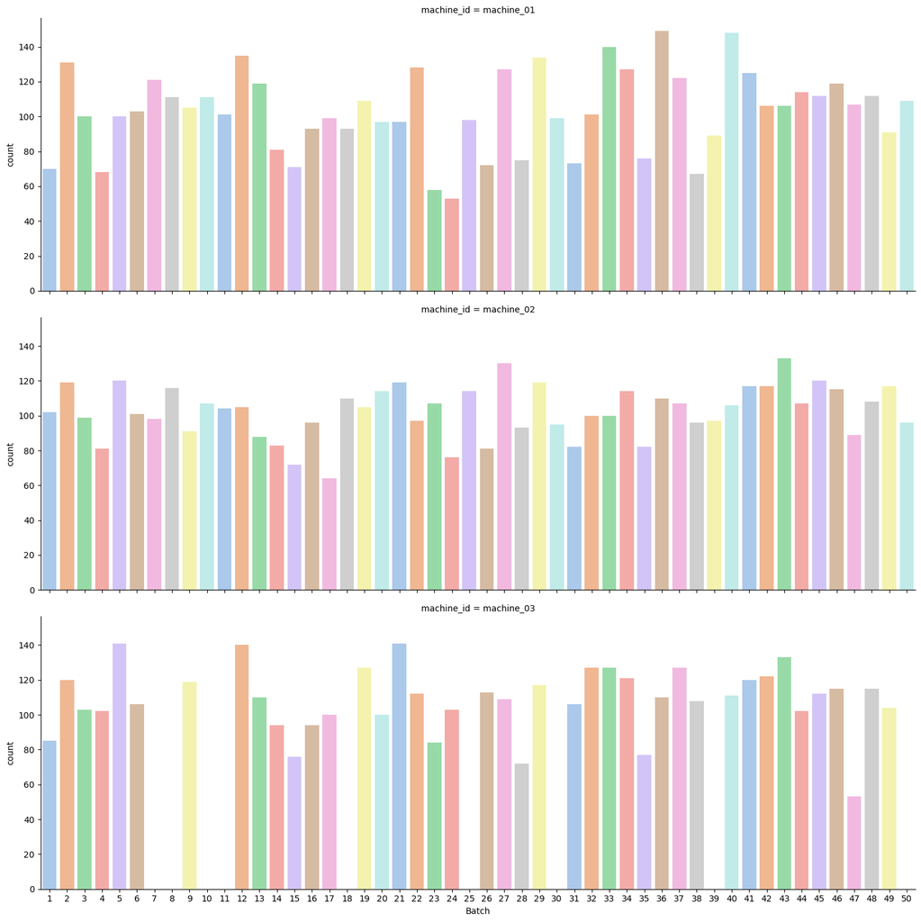

```python
sns.catplot( data = machine_df, x='Batch', row='machine_id', kind='count', aspect=3, palette='pastel')

plt.show()
```

How many cell phone cases are associated with each Batch value for each MACHINE (data set)?

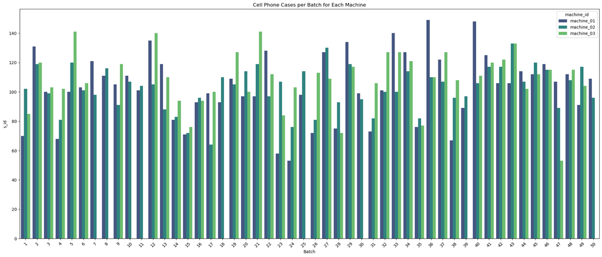

```python
# Count cell phone cases per Machine-Batch combination
cases_per_batch = machine_df.groupby(['machine_id', 'Batch'])['s_id'].count().reset_index()

# Bar plot
plt.figure(figsize=(25, 10))
sns.barplot(x='Batch', y='s_id', hue='machine_id', data=cases_per_batch, palette='viridis')

plt.xlabel("Batch")
plt.ylabel("s_id")
plt.title("Cell Phone Cases per Batch for Each Machine")
plt.legend(title="machine_id")
plt.xticks(rotation=45)
plt.show()
```

Do the summary statistics of the OPERATING VARIABLES x1 through x4 vary across the three MACHINES?

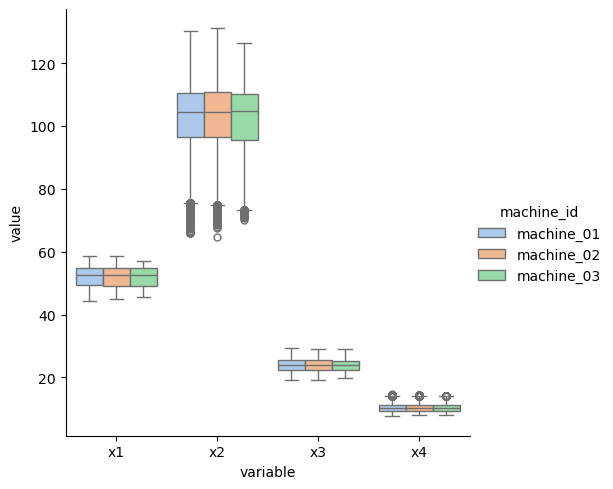

```python
sns.catplot(data = machine_lf, x='variable', y='value', hue='machine_id', kind='box', palette='pastel')

plt.show()
```

Do the summary statistics of the OPERATING VARIABLES x1 through x4 vary across the Batch values?

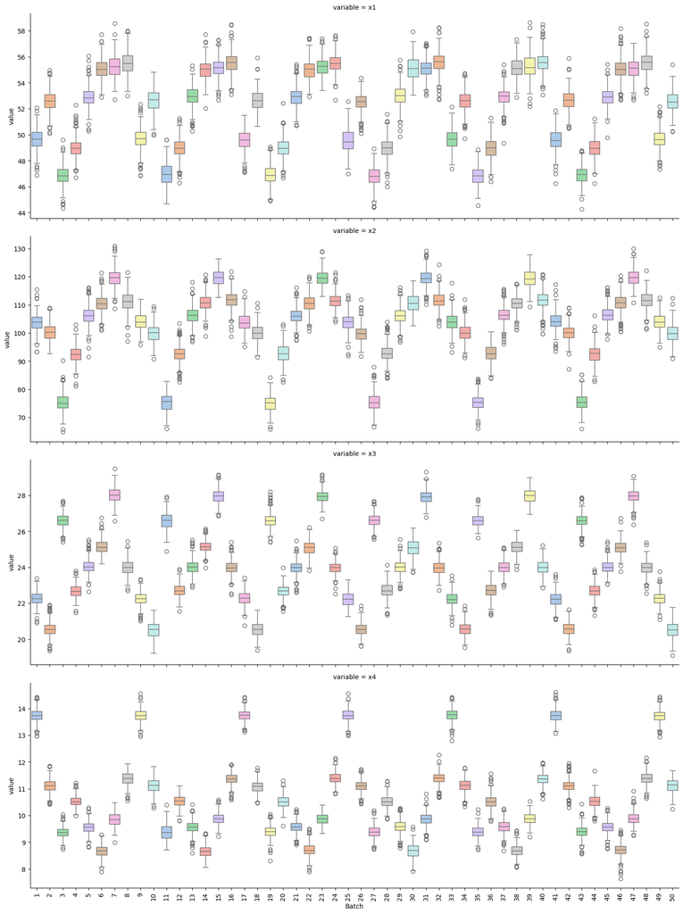

```python
g = sns.FacetGrid(machine_lf, row="variable", sharey=False, height=5, aspect=3)
g.map(sns.boxplot, "Batch", "value", order=sorted(machine_lf["Batch"].unique()), palette='pastel')

plt.xticks(rotation=90)  # Rotate batch labels for better visibility
plt.show()
```

Do the relationships between the OPERATING VARIABLES x1 through x4 vary across the three MACHINES?

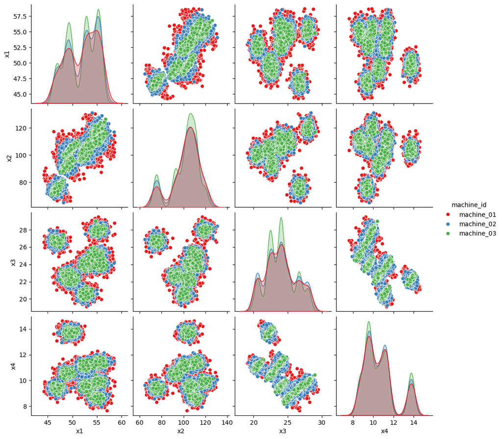

```python
sns.pairplot( data = machine_df.loc[:,['x1', 'x2', 'x3', 'x4', 'machine_id']], hue='machine_id',
             diag_kws={'common_norm':False}, palette='Set1' )

plt.show()
```

Do the relationships between the OPERATING VARIABLES x1 through x4 vary across the Batch values?

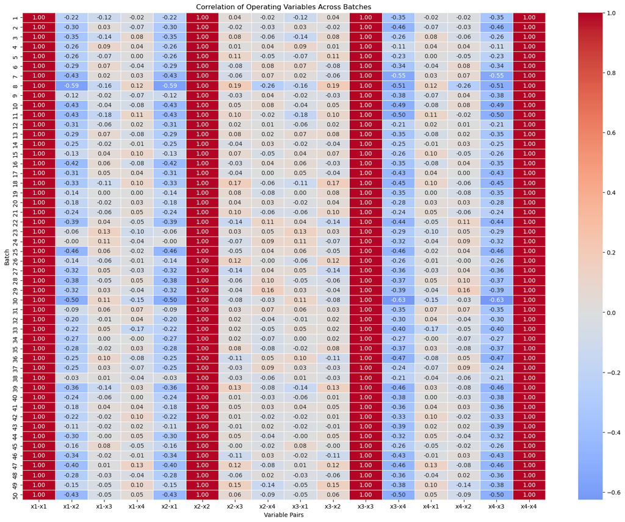

```python
corr_dict = {}
for batch, group in machine_df.groupby("Batch"):
    corr_matrix = group[['x1', 'x2', 'x3', 'x4']].corr()
    corr_dict[batch] = corr_matrix.values.flatten()  # Store as 1D array

# Convert to DataFrame
corr_df = pd.DataFrame(corr_dict, index=pd.MultiIndex.from_tuples(
    [(v1, v2) for v1 in ['x1', 'x2', 'x3', 'x4'] for v2 in ['x1', 'x2', 'x3', 'x4']]
)).T

# Plot the heatmap
plt.figure(figsize=(20, 15))
sns.heatmap(corr_df, cmap="coolwarm", center=0, annot=True, fmt=".2f", linewidths=0.5)
plt.title("Correlation of Operating Variables Across Batches")
plt.xlabel("Variable Pairs")
plt.ylabel("Batch")
plt.show()
```

## Problem 02

The supplier batch data set file name is provided for you below. You must read in the CSV file and assign the data set to the `batch_df` object.

You must perform the following **ESSENTIAL** activities:

- How many rows and columns are in the data?
- What are the names and data types for each column?
- How many unique values are there for each column?
- How many missing values are there for each column?

You must visually explore the MARGINAL behavior of the variables in the data. You must use visualizations appropriate for the DATA TYPE of the columns.

You must visually explore RELATIONSHIPS between variables in the data. You must use visualizations appropriate for the DATA TYPES. You must make sure that your visualizations can answer the following questions:

- Do the summary statistics for `Density` depend on the `Supplier`?
- Does the average `Density` depend on the `Supplier`?
- How does Density relate to `Batch` for each `Supplier`?

After exploring the `batch_df` DataFrame, you **MUST** JOIN/MERGE the `batch_df` DataFrame with the `machine_df` DataFrame. Assign the merged DataFrame to the `dfa` DataFrame.

You can now explore the relationships between the MACHINE OPERATIONAL VARIABLES and the SUPPLIERS! You must use visualizations to explore the following relationships:

- Explore if the summary statistics of the 4 OPERATING VARIABLES `x1` through `x4` vary across `Batch` for each MACHINE given each `Supplier`. You MUST use `Batch` as the x-axis variable.
- Explore if the relationships between the 4 OPERATING VARIABLES `x1` through `x4` vary across `Supplier`.

You may add as many markdown and code cells as you see fit to answer this question.

#### Solution:

```python
# define the batch supplier file
batch_file = 'midterm_supplier.csv'
```

```python
# read in the batch supplier data set

batch_df = pd.read_csv( batch_file )
```

## Number of rows and columns.

```python
batch_df.shape
```

```
(50, 3)
```

## Names and data types for each column.

```python
batch_df.dtypes
```

```
Batch         int64
Supplier     object
Density     float64
dtype: object
```

## Unique values for each column.

```python
batch_df.nunique()
```

```
Batch       50
Supplier     2
Density     50
dtype: int64
```

## Missing values for each column.

```python
batch_df.isna().sum()
```

```
Batch       0
Supplier    0
Density     0
dtype: int64
```

## Converting `Batch` to category.

```python
batch_df["Batch"] = batch_df["Batch"].astype("category")
```

## Marginal behavior of all variables.

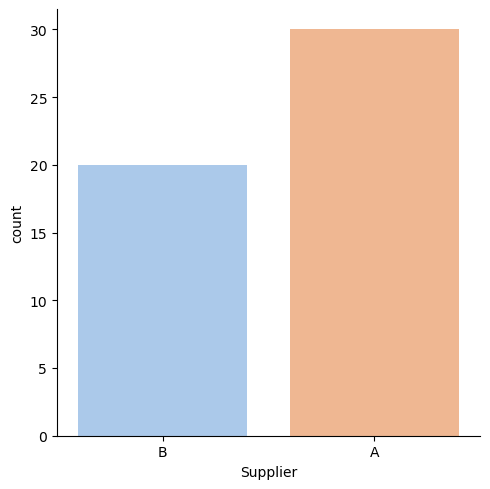

```python
sns.catplot( data = batch_df, x='Supplier', kind='count', palette='pastel')

plt.show()
```

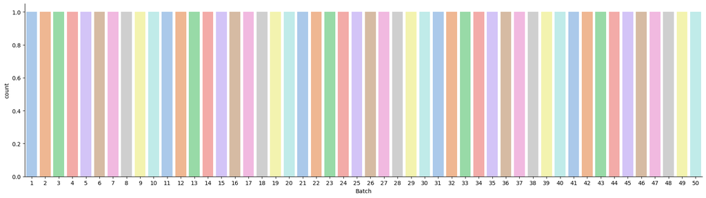

```python
sns.catplot( data = batch_df, x='Batch', kind='count', palette='pastel', aspect=3.5)

plt.show()
```

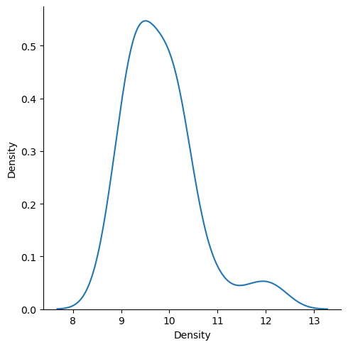

```python
sns.displot(data = batch_df, x='Density', kind='kde')

plt.show()
```

Do the summary statistics for Density depend on the Supplier?

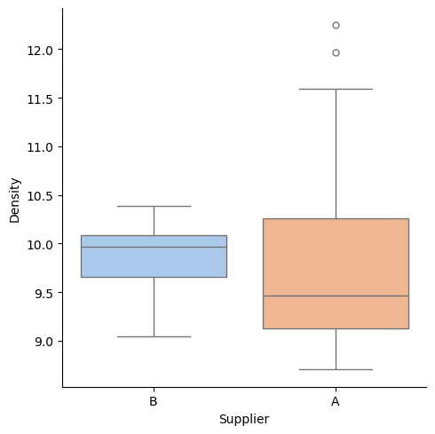

```python
sns.catplot( data = batch_df, x='Supplier', y='Density', hue='Supplier', kind='box', palette='pastel')

plt.show()
```

Does the average Density depend on the Supplier?

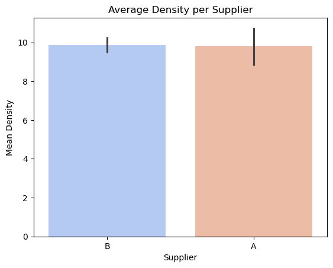

```python
sns.barplot(data=batch_df, x="Supplier", y="Density", palette="coolwarm", estimator=np.mean, ci="sd")
plt.title("Average Density per Supplier")
plt.xlabel("Supplier")
plt.ylabel("Mean Density")

plt.show()
```

How does Density relate to Batch for each Supplier?

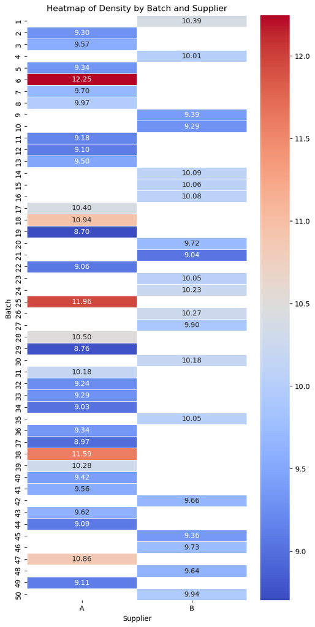

```python
heatmap_data = batch_df.pivot_table(index="Batch", columns="Supplier", values="Density")

plt.figure(figsize=(7, 15))
sns.heatmap(heatmap_data, cmap="coolwarm", annot=True, fmt=".2f", linewidths=0.5)
plt.title("Heatmap of Density by Batch and Supplier")
plt.xlabel("Supplier")
plt.ylabel("Batch")
plt.show()
```

```python
# merge the batch supplier data set with the (concatenated) machine data set

dfa = pd.merge( machine_df, batch_df, on='Batch', how='left')
dfa
```

|  | ID | Batch | s_id | x1 | x2 | x3 | x4 | machine_id | Supplier | Density |
| --- | --- | --- | --- | --- | --- | --- | --- | --- | --- | --- |
| 0 | B001-M01-S001 | 1 | 1 | 50.117118 | 102.167346 | 22.067812 | 13.889524 | machine_01 | B | 10.388587 |
| 1 | B001-M01-S002 | 1 | 2 | 46.887333 | 112.266102 | 23.197330 | 13.064709 | machine_01 | B | 10.388587 |
| 2 | B001-M01-S003 | 1 | 3 | 50.132744 | 103.674908 | 22.319933 | 13.647482 | machine_01 | B | 10.388587 |
| 3 | B001-M01-S004 | 1 | 4 | 48.501042 | 107.143156 | 22.162947 | 14.077758 | machine_01 | B | 10.388587 |
| 4 | B001-M01-S005 | 1 | 5 | 49.690442 | 102.120283 | 22.248696 | 13.728666 | machine_01 | B | 10.388587 |
| ... | ... | ... | ... | ... | ... | ... | ... | ... | ... | ... |
| 14724 | B049-M03-S100 | 49 | 100 | 49.278415 | 102.089925 | 22.396979 | 13.753264 | machine_03 | A | 9.111256 |
| 14725 | B049-M03-S101 | 49 | 101 | 49.264754 | 104.619874 | 21.977716 | 13.636539 | machine_03 | A | 9.111256 |
| 14726 | B049-M03-S102 | 49 | 102 | 49.465358 | 102.867473 | 22.257845 | 13.678206 | machine_03 | A | 9.111256 |
| 14727 | B049-M03-S103 | 49 | 103 | 49.751785 | 104.863427 | 22.461204 | 13.880084 | machine_03 | A | 9.111256 |
| 14728 | B049-M03-S104 | 49 | 104 | 49.819212 | 104.075176 | 22.462165 | 13.853014 | machine_03 | A | 9.111256 |

14729 rows × 10 columns

Wide to Long Format.

```python
dfa_op_var = dfa[['x1', 'x2', 'x3', 'x4',]].copy()
```

```python
dfa_op_var.melt(ignore_index=False)
dfa_op_var
```

|  | x1 | x2 | x3 | x4 |
| --- | --- | --- | --- | --- |
| 0 | 50.117118 | 102.167346 | 22.067812 | 13.889524 |
| 1 | 46.887333 | 112.266102 | 23.197330 | 13.064709 |
| 2 | 50.132744 | 103.674908 | 22.319933 | 13.647482 |
| 3 | 48.501042 | 107.143156 | 22.162947 | 14.077758 |
| 4 | 49.690442 | 102.120283 | 22.248696 | 13.728666 |
| ... | ... | ... | ... | ... |
| 14724 | 49.278415 | 102.089925 | 22.396979 | 13.753264 |
| 14725 | 49.264754 | 104.619874 | 21.977716 | 13.636539 |
| 14726 | 49.465358 | 102.867473 | 22.257845 | 13.678206 |
| 14727 | 49.751785 | 104.863427 | 22.461204 | 13.880084 |
| 14728 | 49.819212 | 104.075176 | 22.462165 | 13.853014 |

14729 rows × 4 columns

```python
dfa_op_var.reset_index().\
rename(columns={'index': 'rowid'}).\
melt(id_vars=['rowid'])
```

|  | rowid | variable | value |
| --- | --- | --- | --- |
| 0 | 0 | x1 | 50.117118 |
| 1 | 1 | x1 | 46.887333 |
| 2 | 2 | x1 | 50.132744 |
| 3 | 3 | x1 | 48.501042 |
| 4 | 4 | x1 | 49.690442 |
| ... | ... | ... | ... |
| 58911 | 14724 | x4 | 13.753264 |
| 58912 | 14725 | x4 | 13.636539 |
| 58913 | 14726 | x4 | 13.678206 |
| 58914 | 14727 | x4 | 13.880084 |
| 58915 | 14728 | x4 | 13.853014 |

58916 rows × 3 columns

```python
dfa_objects = dfa[['ID','Batch','machine_id', 'Supplier']].copy()
```

```python
id_cols=['rowid'] + dfa_objects.columns.to_list()
```

```python
dfa_lf = dfa.reset_index().\
rename(columns={'index': 'rowid'}).\
melt(id_vars=id_cols, value_vars=dfa_op_var.columns)

dfa_lf
```

|  | rowid | ID | Batch | machine_id | Supplier | variable | value |
| --- | --- | --- | --- | --- | --- | --- | --- |
| 0 | 0 | B001-M01-S001 | 1 | machine_01 | B | x1 | 50.117118 |
| 1 | 1 | B001-M01-S002 | 1 | machine_01 | B | x1 | 46.887333 |
| 2 | 2 | B001-M01-S003 | 1 | machine_01 | B | x1 | 50.132744 |
| 3 | 3 | B001-M01-S004 | 1 | machine_01 | B | x1 | 48.501042 |
| 4 | 4 | B001-M01-S005 | 1 | machine_01 | B | x1 | 49.690442 |
| ... | ... | ... | ... | ... | ... | ... | ... |
| 58911 | 14724 | B049-M03-S100 | 49 | machine_03 | A | x4 | 13.753264 |
| 58912 | 14725 | B049-M03-S101 | 49 | machine_03 | A | x4 | 13.636539 |
| 58913 | 14726 | B049-M03-S102 | 49 | machine_03 | A | x4 | 13.678206 |
| 58914 | 14727 | B049-M03-S103 | 49 | machine_03 | A | x4 | 13.880084 |
| 58915 | 14728 | B049-M03-S104 | 49 | machine_03 | A | x4 | 13.853014 |

58916 rows × 7 columns

Explore if the summary statistics of the 4 OPERATING VARIABLES `x1` through `x4` vary across `Batch` for each `MACHINE` given each `Supplier`. Your figures **MUST** use `Batch` as the x-axis variable.

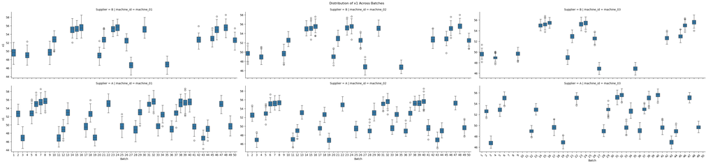

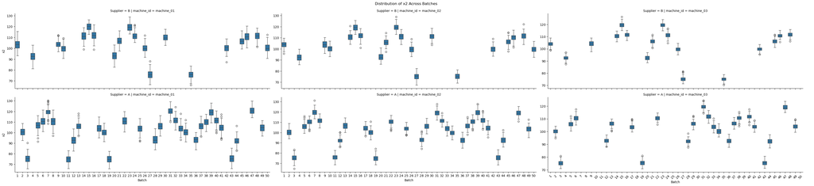

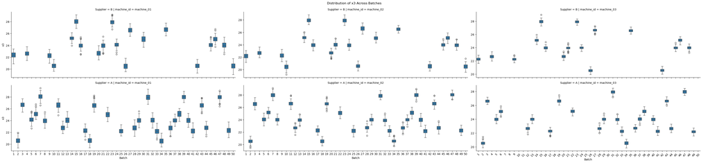

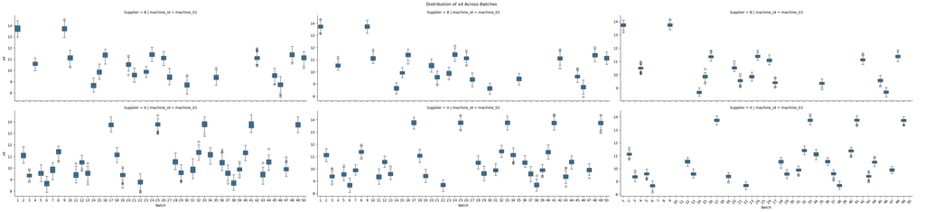

```python
for var in ['x1', 'x2', 'x3', 'x4']:
    g = sns.catplot(
        data=dfa, x="Batch", y=var, col="machine_id", row="Supplier",
        kind="box", height=4, aspect=3, sharey=False
    )
    g.fig.suptitle(f"Distribution of {var} Across Batches", y=1.02)
    plt.xticks(rotation=45)
    plt.show()
```

Explore if the relationships between the 4 OPERATING VARIABLES `x1` through `x4` vary across `Supplier`.

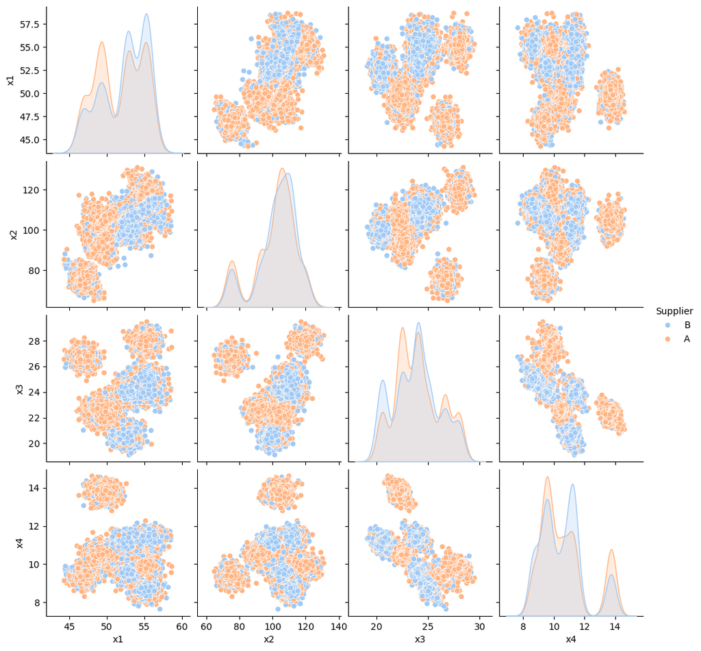

```python
sns.pairplot( data = dfa.loc[:,['x1', 'x2', 'x3', 'x4', 'Supplier']], hue='Supplier',
             diag_kws={'common_norm':False}, palette='pastel' )

plt.show()
```

## Problem 03

The DROP TEST result data set file name is provided for you below. You must read in the CSV file and assign the dta set to the `test_df` object.

You must perform the following **ESSENTIAL** activities:

- How many rows and columns are in the data?
- What are the names and data types for each column?
- How many unique values are there for each column?
- How many missing values are there for each column?

You must visually explore the MARGINAL behavior of the variables in the data. You must use visualizations appropriate for the DATA TYPE of the columns.

You must visually explore RELATIONSHIPS between variables in the data. You must use visualizations appropriate for the DATA TYPES. You must make sure that your visualizations can answer the following questions:

- Count the number of times each unique value of Result occurs for each `test_group_id` value.

After exploring the test_df DataFrame, you **MUST** JOIN/MERGE the `test_df` DataFrame with the dfa DataFrame. Assign the merged DataFrame to the `dfb` DataFrame. You **MUST** answer the following:

- How many rows remain using the DEFAULT joining procedure?

You may add as many markdown and code cells as you see fit to answer this question.

#### SOLUTION

```python
# define the test data set file name
test_file = 'midterm_test.csv'
```

```python
# read in the test data set

test_df = pd.read_csv( test_file )
```

## Number of rows and columns.

```python
test_df.shape
```

```
(1412, 3)
```

## Names and data types for each column.

```python
test_df.dtypes
```

```
ID               object
test_group_id    object
Result            int64
dtype: object
```

## Unique values for each column.

```python
test_df.nunique()
```

```
ID               1412
test_group_id     141
Result              2
dtype: int64
```

## Missing values for each column.

```python
test_df.isna().sum()
```

```
ID               0
test_group_id    0
Result           0
dtype: int64
```

```python
##test_df['Result'] = test_df['Result'].map({0: 'Pass', 1: 'Fail'}).astype('category')
```

## Marginal behavior of all variables.

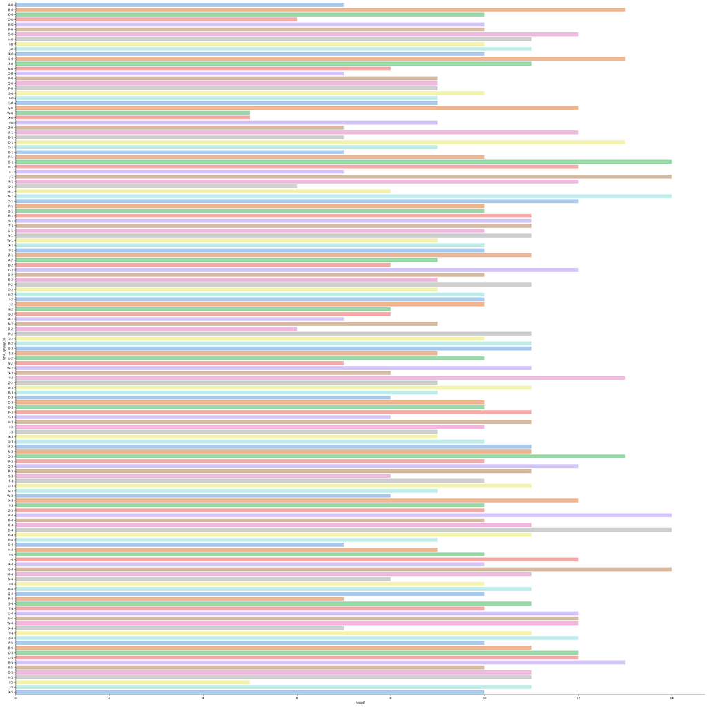

```python
sns.catplot( data = test_df, y='test_group_id', kind='count', palette='pastel', height=30)

plt.show()
```

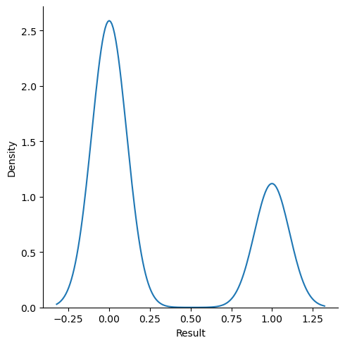

```python
sns.displot( data = test_df, x='Result', kind='kde')

plt.show()
```

Count the number of times each unique value of `Result` occurs for each `test_group_id` value.

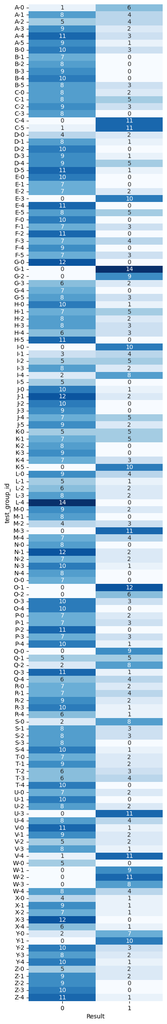

```python
fig, ax = plt.subplots(figsize=(4,30))

sns.heatmap( pd.crosstab( test_df.test_group_id, test_df.Result ), ax=ax,
            annot=True, annot_kws={'size':10}, fmt='d',
            cbar=False, cmap='Blues')

plt.show()
```

```python
# merge test_df with the dfa object

dfb = pd.merge( dfa, test_df, on='ID', how='left')
dfb
```

|  | ID | Batch | s_id | x1 | x2 | x3 | x4 | machine_id | Supplier | Density | test_group_id | Result |
| --- | --- | --- | --- | --- | --- | --- | --- | --- | --- | --- | --- | --- |
| 0 | B001-M01-S001 | 1 | 1 | 50.117118 | 102.167346 | 22.067812 | 13.889524 | machine_01 | B | 10.388587 | NaN | NaN |
| 1 | B001-M01-S002 | 1 | 2 | 46.887333 | 112.266102 | 23.197330 | 13.064709 | machine_01 | B | 10.388587 | A-0 | 1.0 |
| 2 | B001-M01-S003 | 1 | 3 | 50.132744 | 103.674908 | 22.319933 | 13.647482 | machine_01 | B | 10.388587 | NaN | NaN |
| 3 | B001-M01-S004 | 1 | 4 | 48.501042 | 107.143156 | 22.162947 | 14.077758 | machine_01 | B | 10.388587 | NaN | NaN |
| 4 | B001-M01-S005 | 1 | 5 | 49.690442 | 102.120283 | 22.248696 | 13.728666 | machine_01 | B | 10.388587 | NaN | NaN |
| ... | ... | ... | ... | ... | ... | ... | ... | ... | ... | ... | ... | ... |
| 14724 | B049-M03-S100 | 49 | 100 | 49.278415 | 102.089925 | 22.396979 | 13.753264 | machine_03 | A | 9.111256 | NaN | NaN |
| 14725 | B049-M03-S101 | 49 | 101 | 49.264754 | 104.619874 | 21.977716 | 13.636539 | machine_03 | A | 9.111256 | NaN | NaN |
| 14726 | B049-M03-S102 | 49 | 102 | 49.465358 | 102.867473 | 22.257845 | 13.678206 | machine_03 | A | 9.111256 | NaN | NaN |
| 14727 | B049-M03-S103 | 49 | 103 | 49.751785 | 104.863427 | 22.461204 | 13.880084 | machine_03 | A | 9.111256 | NaN | NaN |
| 14728 | B049-M03-S104 | 49 | 104 | 49.819212 | 104.075176 | 22.462165 | 13.853014 | machine_03 | A | 9.111256 | NaN | NaN |

14729 rows × 12 columns

How many rows remain using the DEFAULT joining procedure?

```python
print("Number of rows remaining after default join:", len(dfb))
```

[output not shown]

```python
dfb.isna().sum()
```

```
ID                   0
Batch                0
s_id                 0
x1                   0
x2                   0
x3                   0
x4                   0
machine_id           0
Supplier             0
Density              0
test_group_id    13317
Result           13317
dtype: int64
```

## Problem 04

You must now examine the merged `dfb` object and answer the following:

- Count the number of times each unique value of `Result` occurs for each value of `machine_id`.
- Count the number of times each unique value of `Result` occurs for each value of `Supplier`.
- Visualize the number of times each unique value of `Result` occurs per `Batch` for each value of `machine_id`.
- Visualize the number of times each unique value of `Result` occurs per `Batch` for each value of `machine_id` and `Supplier`.
- Calculate the PROPORTION of times the cell phone case failed the test in each `Batch` per `machine_id`.
- Visualize the PROPORTION of times the cell phone case failed the test in each `Batch` per `machine_id` and for each unique value of `Supplier`.

HINT: Remember that a FAILED test is encoded as Result == 1. How can you calculate the PROPORTION of times Result == 1?`

Add as many cells as you see fit to answer this question.

#### SOLUTION

Count the number of times each unique value of `Result` occurs for each value of `machine_id`.

```python
dfb_counts = dfb.groupby(['machine_id', 'Result']).size().unstack(fill_value=0)
dfb_counts = dfb_counts.rename(columns={0: 'Pass', 1: 'Fail', pd.NA: 'Missing'})

print(dfb_counts)
```

```
Result      Pass  Fail
machine_id
machine_01   333   159
machine_02   342   147
machine_03   311   120
```

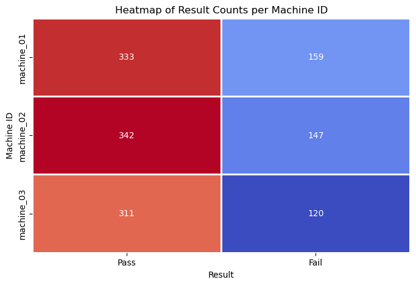

```python
plt.figure(figsize=(8,5))
sns.heatmap(dfb_counts, annot=True, cmap="coolwarm", fmt="d", linewidths=1, cbar=False)

plt.title("Heatmap of Result Counts per Machine ID")
plt.xlabel("Result")
plt.ylabel("Machine ID")
plt.show()
```

Count the number of times each unique value of `Result` occurs for each value of `Supplier`.

```python
dfb_counts2 = dfb.groupby(['Supplier', 'Result']).size().unstack(fill_value=0)
dfb_counts2 = dfb_counts2.rename(columns={0: 'Pass', 1: 'Fail', pd.NA: 'Missing'})

print(dfb_counts2)
```

```
Result    Pass  Fail
Supplier
A          588   290
B          398   136
```

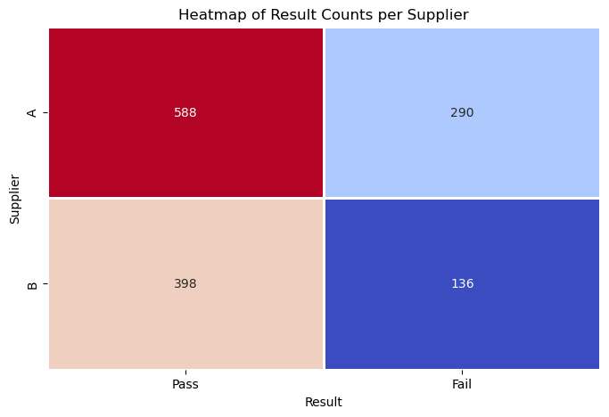

```python
plt.figure(figsize=(8,5))
sns.heatmap(dfb_counts2, annot=True, cmap="coolwarm", fmt="d", linewidths=1, cbar=False)

plt.title("Heatmap of Result Counts per Supplier")
plt.xlabel("Result")
plt.ylabel("Supplier")
plt.show()
```

Visualize the number of times each unique value of `Result` occurs per `Batch` for each value of `machine_id`.

```python
dfb_counts3 = dfb.groupby(['machine_id', 'Batch', 'Result']).size().unstack(fill_value=0)
dfb_counts3 = dfb_counts3.rename(columns={0: 'Pass', 1: 'Fail', pd.NA: 'Missing'})

print(dfb_counts3.reset_index())
```

```
Result  machine_id Batch  Pass  Fail
0       machine_01     1     1     6
1       machine_01     2    10     3
2       machine_01     3     8     2
3       machine_01     4     4     2
4       machine_01     5    10     0
..             ...   ...   ...   ...
145     machine_03    46    11     0
146     machine_03    47     5     0
147     machine_03    48     9     2
148     machine_03    49     0    10
149     machine_03    50     0     0

[150 rows x 4 columns]
```

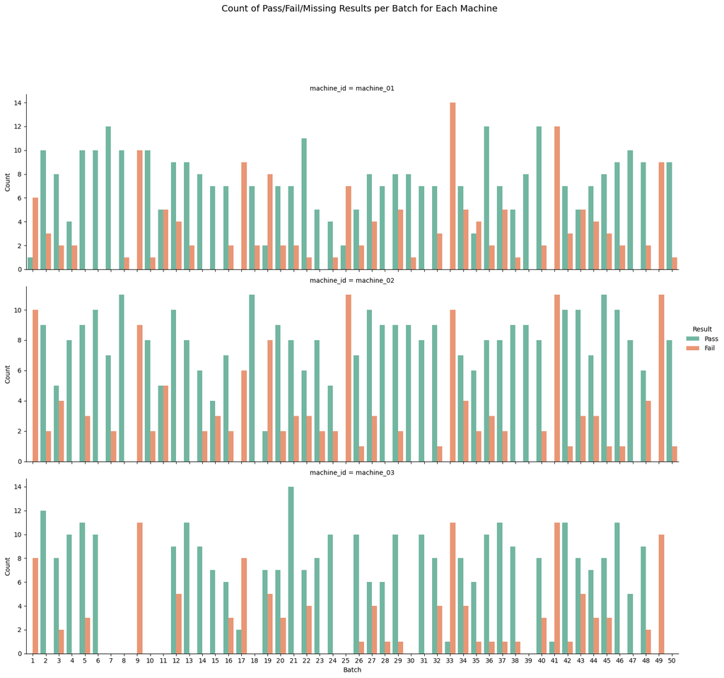

```python
dfb_long = dfb_counts3.reset_index().melt(id_vars=['machine_id', 'Batch'],
                                       var_name='Result', value_name='Count')


plt.figure(figsize=(12,6))
sns.catplot(data=dfb_long, x='Batch', y='Count', hue='Result', col='machine_id',
            kind='bar', col_wrap=1, palette="Set2", sharey=False, aspect=3)

plt.subplots_adjust(top=0.85)
plt.suptitle("Count of Pass/Fail/Missing Results per Batch for Each Machine", fontsize=14)
plt.show()
```

Visualize the number of times each unique value of `Result` occurs per `Batch` for each value of `machine_id` and `Supplier`.

```python
dfb_counts4 = dfb.groupby(['machine_id', 'Supplier', 'Batch', 'Result']).size().unstack(fill_value=0)

# Rename columns for better understanding
dfb_counts4 = dfb_counts4.rename(columns={0: 'Pass', 1: 'Fail', pd.NA: 'Missing'})

print(dfb_counts4.reset_index())
```

```
Result  machine_id Supplier Batch  Pass  Fail
0       machine_01        A     1     0     0
1       machine_01        A     2    10     3
2       machine_01        A     3     8     2
3       machine_01        A     4     0     0
4       machine_01        A     5    10     0
..             ...      ...   ...   ...   ...
295     machine_03        B    46    11     0
296     machine_03        B    47     0     0
297     machine_03        B    48     9     2
298     machine_03        B    49     0     0
299     machine_03        B    50     0     0

[300 rows x 5 columns]
```

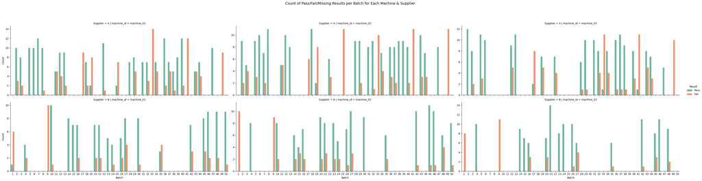

```python
# Convert the count DataFrame into a long format for easy plotting
dfb_long = dfb_counts4.reset_index().melt(id_vars=['machine_id', 'Supplier', 'Batch'],
                                       var_name='Result', value_name='Count')

# Create a grouped bar chart with facet grid
plt.figure(figsize=(15,9))
sns.catplot(data=dfb_long, x='Batch', y='Count', hue='Result', col='machine_id', row='Supplier',
            kind='bar', palette="Set2", sharey=False, aspect=2.5)

plt.subplots_adjust(top=0.85)
plt.suptitle("Count of Pass/Fail/Missing Results per Batch for Each Machine & Supplier", fontsize=14)

plt.show()
```

Calculate the PROPORTION of times the cell phone case failed the test in each `Batch` per `machine_id`.

```python
# Exclude NaN values before calculating the failure proportion
dfb_non_na = dfb.dropna(subset=['Result'])

# Count total tests per Batch, Machine, and Supplier (excluding NaNs)
total_tests = dfb_non_na.groupby(['machine_id', 'Batch'])['Result'].count()

# Count failures (Result == 1) per Batch, Machine, and Supplier
failures = dfb_non_na[dfb_non_na['Result'] == 1].groupby(['machine_id', 'Batch'])['Result'].count()

# Compute failure proportion
failure_proportion = (failures / total_tests).fillna(0)  # Fill NaNs with 0 in case there were no failures

# Convert to DataFrame
failure_proportion_dfb = failure_proportion.reset_index().rename(columns={'Result': 'Failure_Proportion'})

print(failure_proportion_dfb)
```

```
     machine_id Batch  Failure_Proportion
0    machine_01     1            0.857143
1    machine_01     2            0.230769
2    machine_01     3            0.200000
3    machine_01     4            0.333333
4    machine_01     5            0.000000
..          ...   ...                 ...
145  machine_03    46            0.000000
146  machine_03    47            0.000000
147  machine_03    48            0.181818
148  machine_03    49            1.000000
149  machine_03    50            0.000000

[150 rows x 3 columns]
```

Visualize the PROPORTION of times the cell phone case failed the test in each `Batch` per `machine_id` and for each unique value of `Supplier`.

```python
# Exclude NaN values before calculating the failure proportion
df_non_na = dfb.dropna(subset=['Result'])

# Count total tests per Batch, Machine, and Supplier (excluding NaNs)
total_tests2 = df_non_na.groupby(['machine_id', 'Supplier', 'Batch'])['Result'].count()

# Count failures (Result == 1) per Batch, Machine, and Supplier
failures2 = df_non_na[df_non_na['Result'] == 1].groupby(['machine_id', 'Supplier', 'Batch'])['Result'].count()

# Compute failure proportion
failure_proportion2 = (failures2 / total_tests2).fillna(0)  # Fill NaNs with 0 in case there were no failures

# Convert to DataFrame
failure_proportion_dfb2 = failure_proportion2.reset_index().rename(columns={'Result': 'Failure_Proportion'})

print(failure_proportion_dfb2)
```

```
     machine_id Supplier Batch  Failure_Proportion
0    machine_01        A     1            0.000000
1    machine_01        A     2            0.230769
2    machine_01        A     3            0.200000
3    machine_01        A     4            0.000000
4    machine_01        A     5            0.000000
..          ...      ...   ...                 ...
295  machine_03        B    46            0.000000
296  machine_03        B    47            0.000000
297  machine_03        B    48            0.181818
298  machine_03        B    49            0.000000
299  machine_03        B    50            0.000000

[300 rows x 4 columns]
```

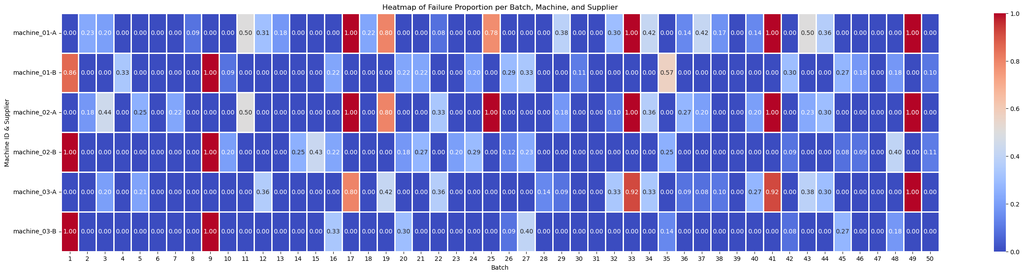

```python
plt.figure(figsize=(32,7))
failure_pivot = failure_proportion_dfb2.pivot(index=['machine_id', 'Supplier'], columns='Batch', values='Failure_Proportion')

sns.heatmap(failure_pivot, annot=True, cmap="coolwarm", linewidths=1, fmt=".2f", vmin=0, vmax=1)

plt.title("Heatmap of Failure Proportion per Batch, Machine, and Supplier")
plt.xlabel("Batch")
plt.ylabel("Machine ID & Supplier")

plt.show()
```